# Analysis of gender pay gap of newly-graduated maths/stats students across different percentiles.

Owen F. O’Connor

2025-03-14

```r
library(tidyverse)
```

## Introduction

This analysis focuses on graduates with a Level 8 degree in Natural Sciences, Mathematics, and Statistics, examining the pay gap across 3 different pay groupings.

```r
library(tidyverse)
load("../gradMS.Rdata")

# Data cleaning / pre-processing
# gradMS[,1] # statistic
# gradMS[,2] # year
# gradMS[,3] # gender
# gradMS[,4] # field of study
# gradMS[,5] # NFQ Level
# gradMS[,6] # years since graduation
# gradMS[,7] # measure of statistic

# field of study and NFQ are irrelevant since they're always the same. We can remove them
# gradMS <- gradMS[,-c(4,5)]
# gradMS[,1] # statistic
# gradMS[,2] # year
# gradMS[,3] # gender
# gradMS[,4] # years since graduation
# gradMS[,5] # measure of statistic

gradMS %>%
  filter(Gender == "Other gender")
# there only exists one observations
# we can't make any meaningful analysis off of one point.
# We are hence deciding to omit this data

gradMS <- gradMS %>%
  filter(Gender != "Other gender") # this removes 300 rows

# we think it'd also make sense to pivot this table wider
# Increases readability and will make ggplots easier

gradMS_wider <- gradMS |> # we use a base pipe here because magrittr pipes play weird with '.'
  pivot_wider(names_from = Statistic, values_from = .)

# Some of these names are awkward, so we'll simplify them.
gradMS_wider <- gradMS_wider %>%
  rename(
    p25 = `P25 Earnings of Graduates`,
    p50 = `P50 Earnings of Graduates`,
    p75 = `P75 Earnings of Graduates`
  )
```

```r
gradMS_Q1 <- gradMS_wider %>%
  filter(Gender != "All genders") %>%
  filter(Years.Since.Graduation == 1) %>%
  select(!Years.Since.Graduation) %>%
  pivot_wider(names_from = Gender, values_from = c(p25, p50, p75)) %>%
  mutate(
    Pay.dif.p25 = (p25_Male / p25_Female) - 1,
    Pay.dif.p50 = (p50_Male / p50_Female) - 1,
    Pay.dif.p75 = (p75_Male / p75_Female) - 1
  )

gradMS_Q1_final <- gradMS_Q1 %>%
  pivot_longer(
    cols = c(Pay.dif.p25, Pay.dif.p50, Pay.dif.p75),
    names_to = "Percentile",
    values_to = "Pay_Ratio"
  ) %>%
  # Create factor with levels in desired order (p75 at top, p25 at bottom)
  mutate(Percentile = factor(Percentile,
                             levels = c("Pay.dif.p75", "Pay.dif.p50", "Pay.dif.p25"),
                             labels = c("75th Percentile", "50th Percentile", "25th Percentile"))) %>%
  select(Graduation.Year, Percentile, Pay_Ratio)
```

## Including Plots

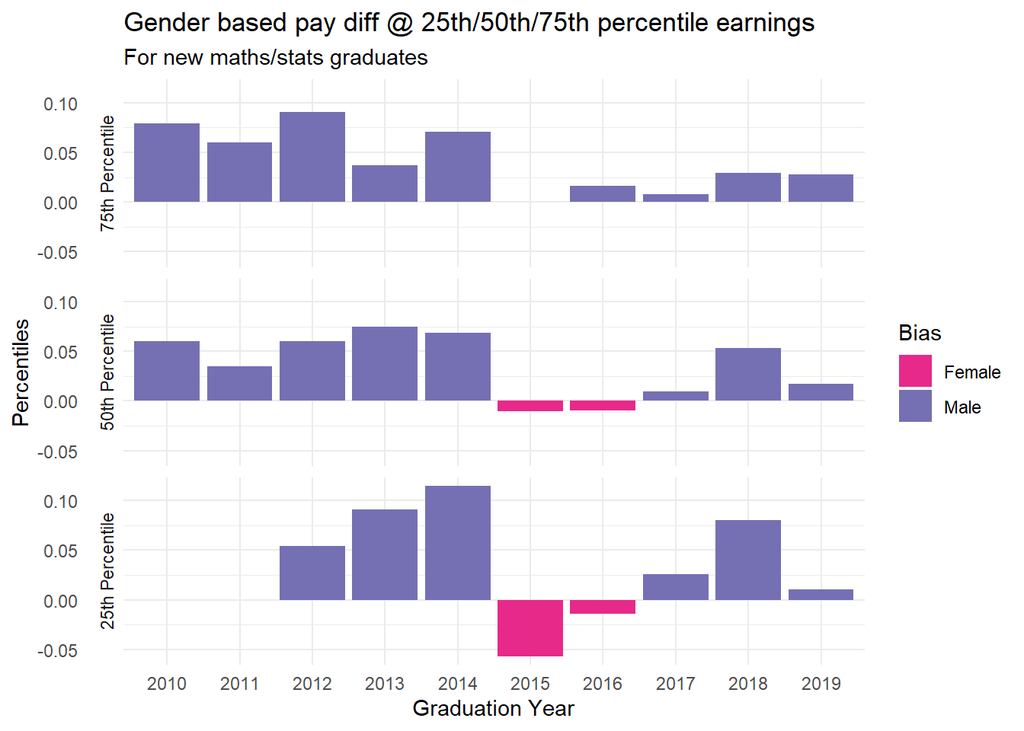

```r
gradMS_Q1_final %>%
  mutate(Graduation.Year = as.factor(Graduation.Year)) %>%
  ggplot(aes(x = Graduation.Year, y = Pay_Ratio, fill = Pay_Ratio > 0)) +
  geom_bar(stat = "identity") +
  facet_grid(Percentile ~ ., switch = "y") +
  scale_fill_manual(values = c("#E7298AFF", "#7570B3FF"),
                    name = "Bias",
                    labels = c("Female", "Male")) +
  theme_minimal() +
  labs(title = "Gender based pay diff @ 25th/50th/75th percentile earnings",
       subtitle = "For new maths/stats graduates",
       y = "Percentiles",
       x = "Graduation Year")
```

This plot illustrates the gender pay gap for recent mathematics and statistics graduates at the 25th, 50th, and 75th earnings percentiles, measured one year after graduation.

Overall, a consistent bias toward male graduates is evident across most years and percentiles, particularly at the 75th percentile, where men consistently earn more than women in the early and later years. The median (50th percentile) also reflects a male pay advantage in most cohorts.

A notable exception occurs around 2015, where the trend temporarily reverses:

- At the 25th percentile, there is a pronounced female advantage, with women earning more than men in two consecutive years.
- This reversal is present to a lesser extent at the median, and absent at the 75th percentile, suggesting the pay gap reversal was concentrated among lower-earning graduates.

By 2018, the male advantage reasserts itself across all percentiles, particularly at the lower end of the payscale.

From this graphic we may gather that there have been short-term changes in salary practices.  
The persistent bias at the top end informs us to the structural dynamics disproportionately benefiting men in higher-paying positions.